# Statistics are useless without suitable data: How to implement and assess for data quality

Erin M. Buchanan & Flavio Azevedo

7/9/2019

# Materials

- OSF: https://osf.io/x53kn/
- GitHub: https://github.com/doomlab/Data-Quality-Controls
- Mendeley: Reading list will be shared on OSF
- RStudio: https://rstudio.cloud/project/405564
- Follow us:
  - erin: @aggieerin, Statistics of Doom YouTube
  - Flavio: @Flavio_Azevedo_

# Overview

- Definitions: quality data
- Example dataset
- Checks and controls
  - How to implement
  - How to analyze
- What difference does it make?

# What is quality data?

- Might be better to ask: what is bad data?
- Some ideas:
  - Data not from the population you intended (sampling)
  - Data from the population you intended but extreme (true outliers)
  - Social desirability responding
  - Misunderstanding of the instructions
  - Low effort data provided by participants
  - Automated or otherwise “fake” data

# What is quality data?

- Data that is:
  - Provided by a real participant
  - Complies with instructions
  - Good faith effort by participants
- Any other thoughts?
- *Note*: all these are regardless of your hypotheses!

# What is quality data?

- A strong definition of what you think data quality is in the context of your study will help you determine how to control for quality.
- Pre-planned checks are good! Pre-registered plans are great!
- Post hoc checking is also cool, but be careful of peaking and using it to *p*-hack

# Quality participants?

- Sorry guys, you provide bad data
- Younger participants (less) versus older participants (more)
- Financial/hourly workers (less) versus professionals (more)
- Students? - related to GPA
- Non-US participants (less)
- Related to some personality measures

# Why should we care about DQ?

- Added noise to a study can:
  - Decrease power
  - Decrease reliability
  - Change the summary and test statistics
  - Decrease reproducibility*

# What we are going to do

- Prevention versus Treatment
  - [Open Sampling Workshop](https://docs.google.com/document/d/1Y0TY49qGmzWXyHP81pKS5bR_QGVET2N0HqC4Dw6pQsU/edit)
  - What can we do to help participants want to take our studies correctly? (prevention)
  - What can we do to clean up the mess afterwards? (treatment)
  - Focus on treatment with a bit of prevention
- Focus on individual measures of DQ assessment - rather than global study measures like Cronbach’s $\alpha$
- Explore visible (obtrusive) versus invisible DQ measures

# Where to put DQ checks?

- Data screening is important!
- More than just assumptions of linearity, normality, etc.
- Accuracy –> missing data –> DQ / outliers –> assumptions

# Real Example!

- Question: What is the relationship between meaning, resiliency, and psychological flexibility?
- Hypothesis: These should be highly correlated (some positive, some negative)
  - Going to explore the effects of different screeners on a high and low correlation

# Participants

- Sample: 328 MTurk Participants
  - 60% HIT rate
  - At least 100 HITs
  - Run on TurkPrime
- Survey took approximately ~10 minutes (5.32)
  - $7.25 * 10/60 = 1.21
  - HITS were paid at $1.25
  - Prevention!

# Participants

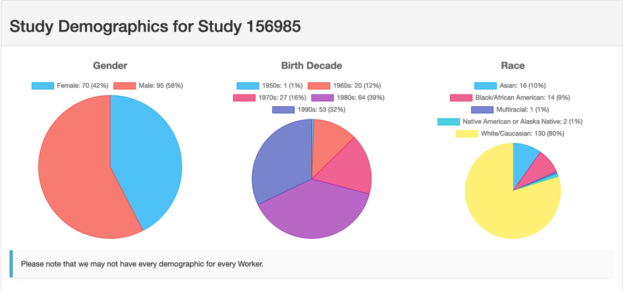

Turk Prime Sample

# Materials

- Resiliency Scale 14 Items
- Meaning in Life Questionnaire
- Multidimensional Psychological Flexibility Inventory
- Attentive Responding Scale (obtrusive measure)

# Procedure

- Qualtrics survey randomly assigned to conditions
  - FULL group: all surveys and visible attention checks
  - PARTIAL group: all surveys, no visible checks
  - *n*s = 164, 164
- Survey order:
  - Consent, demographics, ARS part 1
  - Random order of MLQ, RS14, MPFI (two pages)
  - ARS part 2
  - Ask if serious question
  - Thanks!
- Randomization is important because DQ is poorer at the end of a study (prevention)

# Hypothesis Test

- Focus on flexibility + resiliency (high), resiliency + search (low)

| Group | F-R | R-S |
| --- | --- | --- |
| Overall | $r = .72$, 95% CI $[.66$, $.77]$ | $r = .15$, 95% CI $[.04$, $.26]$ |
| Full | $r = .76$, 95% CI $[.68$, $.82]$ | $r = .12$, 95% CI $[-.03$, $.28]$ |
| Partial | $r = .70$, 95% CI $[.60$, $.77]$ | $r = .18$, 95% CI $[.02$, $.33]$ |

# Let’s get to checking!

- Visible
  - Attention checks, check questions, manipulation questions
  - Inattention measures
  - Self-report attention
  - Captcha *
- Invisible
  - Speeding
  - Meta-data checks
  - Response patterns

# Attention Checks

- Items that somehow inform if the participant is paying attention
- Can be coded as “correct/incorrect”
- Many forms:
  - Please mark strongly agree
  - Manipulation check for the study instructions
  - Asking the same demographic questions twice (beginning/end)

# Attention Checks

[figure not shown]

Attention Check Idea

# How to Implement

- You can randomly embed these items on pages with other questions or simply put them as their own page.
- In this study, I put one on each page for the real surveys (four total).
- Questions:
  - `flex_answer4` = “I was able to move on by selecting Often TRUE to this statement”
  - `inflex_answer2` = “I mindlessly will choose the answer Rarely TRUE to this question”
  - `rs_answer6` = “I believe in myself that I selected Agree to this question.”
  - `mlq_answer6` = “My life’s meaning is centered around choosing mostly true for this question.”

# How to Score

- Global Suggestions:
  - Keep a summary column of each check, so you can exclude folks based on the overall “attentiveness” rather than one individual check
  - More than one check should be used to determine who you might exclude
  - Figure out how many checks you will have and determine a percent or proportion “cut off” to use

# How to Score

```r
master$attention_total <- as.numeric(master$flex_answer4 != 4) +
  as.numeric(master$inflex_answer2 != 2) + as.numeric(master$rs_answer6 != 6) +
  as.numeric(master$mlq_answer6 != 6)

prop.table(table(master$attention_total))  * 100
```

```
##
##         0         1         2         3         4
## 68.711656 13.496933 10.429448  3.680982  3.680982
```

# Effect on Statistical Test

| Attn Check Cut-Off | F-R | R-S |
| --- | --- | --- |
| Original | $r = .76$, 95% CI $[.68$, $.82]$ | $r = .12$, 95% CI $[-.03$, $.28]$ |
| < 4 Incorrect | $r = .73$, 95% CI $[.64$, $.80]$ | $r = .06$, 95% CI $[-.10$, $.22]$ |
| < 3 Incorrect | $r = .73$, 95% CI $[.64$, $.80]$ | $r = .05$, 95% CI $[-.11$, $.21]$ |
| < 2 Incorrect | $r = .73$, 95% CI $[.63$, $.80]$ | $r = .02$, 95% CI $[-.15$, $.19]$ |
| All Correct | $r = .74$, 95% CI $[.63$, $.81]$ | $r = .00$, 95% CI $[-.18$, $.19]$ |

# Inattention Measures

- Ad hoc scales that you can use to measure “inattention”
- Work similarly to attention checks, but less obvious what the cut off score is
- Implement simply as a scale in your study

# Inattention Measures

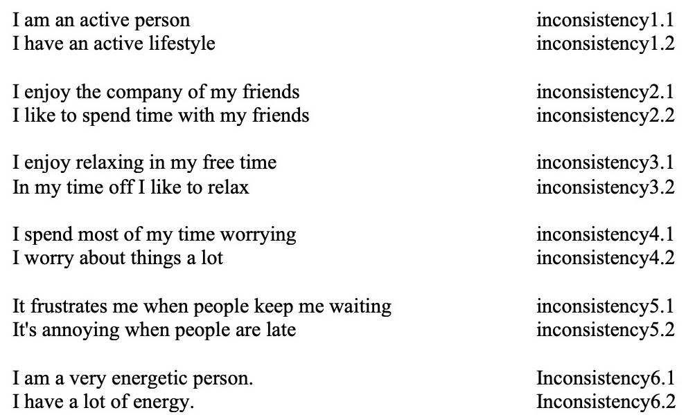

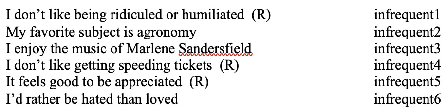

# How to Score

- Total the absolute difference between pairs of items for the inconsistency scale
- Suggested cut-off: 6.5

```r
master$inconsistent_total <- abs(master$inconsistent1.1 - master$inconsistent1.2) +
  abs(master$inconsistent2.1 - master$inconsistent2.2) +
  abs(master$inconsistent3.1 - master$inconsistent3.2) +
  abs(master$inconsistent4.1 - master$inconsistent4.2) +
  abs(master$inconsistent5.1 - master$inconsistent5.2) +
  abs(master$inconsistent6.1 - master$inconsistent6.2)

master$inconsistent_check <- master$inconsistent_total <= 6.5

prop.table(table(master$inconsistent_check)) * 100
```

```
##
##     FALSE      TRUE
##  9.090909 90.909091
```

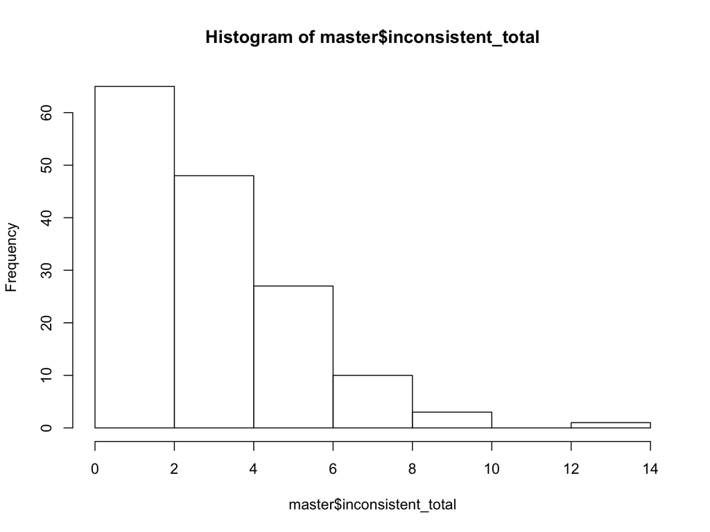

```r
hist(master$inconsistent_total)
```

# How to Score

- Sum the infrequency items (note: some are reversed)
- Suggested cut-off: 7.5

```r
master$infrequent_total <- master$infrequent1 + master$infrequent2 + master$infrequent3 +
  master$infrequent4 + master$infrequent5 + master$infrequent6

master$infrequent_check <- master$infrequent_total <= 7.5

prop.table(table(master$infrequent_check)) * 100
```

```
##
## FALSE  TRUE
##    35    65
```

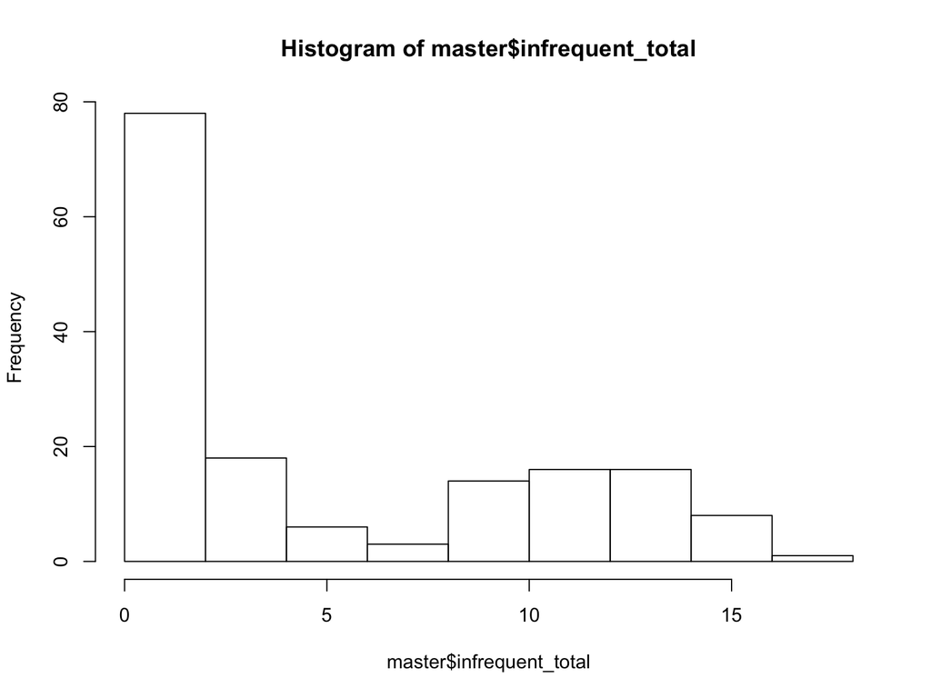

```r
hist(master$infrequent_total)
```

# Effect on Statistical Test

| Measure | F-R | R-S |
| --- | --- | --- |
| Original | $r = .76$, 95% CI $[.68$, $.82]$ | $r = .12$, 95% CI $[-.03$, $.28]$ |
| Below Inconsistent Total | $r = .78$, 95% CI $[.70$, $.84]$ | $r = .07$, 95% CI $[-.10$, $.24]$ |
| Below Infrequent Total | $r = .74$, 95% CI $[.64$, $.82]$ | $r = -.03$, 95% CI $[-.22$, $.17]$ |
| Below Both | $r = .78$, 95% CI $[.69$, $.85]$ | $r = -.09$, 95% CI $[-.29$, $.11]$ |

# Self-report Attention

- Simply ask the participants to report their attention

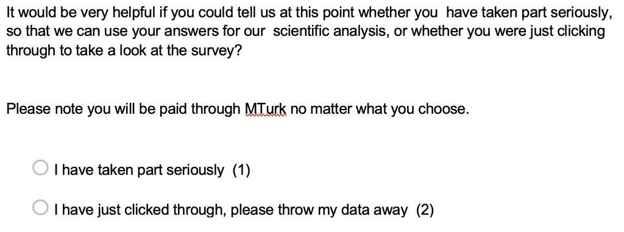

Self-Report Attention

# How to Score

- Simply use their answer!

```r
prop.table(table(master$seriouscheck, master$surveygroup))*100
```

```
##
##                              FULL    PARTIAL
##                         0.6097561  0.3048780
##   Just clicked through  2.1341463  3.9634146
##   Seriously            47.2560976 45.7317073
```

# Effect on Statistical Test

| Measure | F-R | R-S |
| --- | --- | --- |
| Original Full | $r = .76$, 95% CI $[.68$, $.82]$ | $r = .12$, 95% CI $[-.03$, $.28]$ |
| Full Survey | $r = .75$, 95% CI $[.67$, $.82]$ | $r = .10$, 95% CI $[-.06$, $.25]$ |
| Original Partial | $r = .70$, 95% CI $[.60$, $.77]$ | $r = .18$, 95% CI $[.02$, $.33]$ |
| Partial Survey | $r = .70$, 95% CI $[.61$, $.78]$ | $r = .14$, 95% CI $[-.02$, $.31]$ |

# Speeding

- “Rushing” through the study
- There are a LOT of thoughts on speeding cut-offs:
  - 1-2 seconds per item
  - 300 ms per word
  - 600 words per minute (~100 ms per word)
  - Character counts

# How to Implement

- Qualtrics: you can easily add a page timing question to get each page’s time
- Others experiences?
- You can use the whole survey submission time as well
- Decision:
  - Do I screen each page?
  - Do I screen the whole thing?
  - What do I do with very long response times?

# How to Score

- Determine cut-off and see how many people are below it

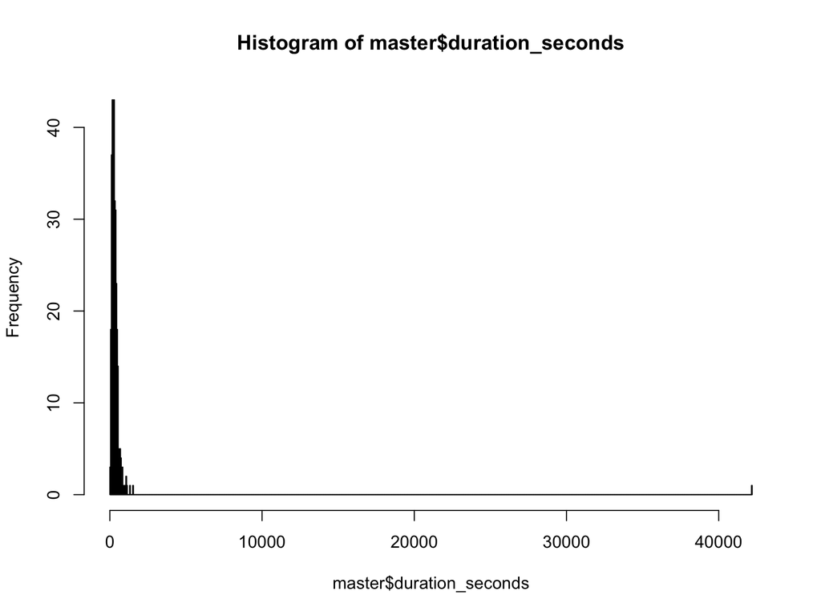

# How to Score

- If you use the whole survey time, per word options may be best

```r
words <- 1946
short_words <- (words * 100) / 1000 #convert to seconds
long_words <- words * 300 / 1000

master$short_words <- master$duration_seconds >= short_words
master$long_words <- master$duration_seconds >= long_words

prop.table(table(master$short_words)) * 100
```

```
##
##    FALSE     TRUE
## 28.04878 71.95122
```

```r
prop.table(table(master$long_words)) * 100
```

```
##
##     FALSE      TRUE
## 91.463415  8.536585
```

# How to Score

- If you use page time, per item or character options may be best

```r
items <- 14

master$RSpage_items <- master$Q9_Page.Submit >= items

prop.table(table(master$RSpage_items)) * 100
```

```
##
##     FALSE      TRUE
##  4.878049 95.121951
```

```r
characters <- 1137
meanchar <- 987
sdchar <- 118
upperchar <- meanchar + 2*sdchar
cutoffChar <- characters / upperchar * 60

master$RSpage_char <- master$Q9_Page.Submit >= cutoffChar

prop.table(table(master$RSpage_char)) * 100
```

```
##
##    FALSE     TRUE
## 60.97561 39.02439
```

# Effect on Statistical Test

| Measure | F-R | R-S |
| --- | --- | --- |
| Original Full | $r = .76$, 95% CI $[.68$, $.82]$ | $r = .12$, 95% CI $[-.03$, $.28]$ |
| Full 100ms word | $r = .71$, 95% CI $[.62$, $.79]$ | $r = .06$, 95% CI $[-.12$, $.23]$ |
| Full 1s item | $r = .73$, 95% CI $[.65$, $.80]$ | $r = .05$, 95% CI $[-.11$, $.20]$ |
| Original Partial | $r = .70$, 95% CI $[.60$, $.77]$ | $r = .18$, 95% CI $[.02$, $.33]$ |
| Partial 100ms word | $r = .68$, 95% CI $[.55$, $.78]$ | $r = -.09$, 95% CI $[-.28$, $.12]$ |
| Partial 1s item | $r = .69$, 95% CI $[.59$, $.77]$ | $r = .13$, 95% CI $[-.04$, $.29]$ |

# Meta-Data Checks - IPs

- IP Duplication
- Bad IPs - package `rIP` or use https://ipinfo.info/html/ip_checker.php
- https://itaysisso.shinyapps.io/bots

```r
ip_table <- as.data.frame(table(master$IP))

master$IP_check <- master$IP %in% ip_table$Var1[ip_table$Freq == 1]

prop.table(table(master$IP_check)) * 100
```

```
##
##    FALSE     TRUE
## 29.26829 70.73171
```

# Effect on Statistical Test

| Measure | F-R | R-S |
| --- | --- | --- |
| Original Full | $r = .76$, 95% CI $[.68$, $.82]$ | $r = .12$, 95% CI $[-.03$, $.28]$ |
| Full IP | $r = .73$, 95% CI $[.63$, $.81]$ | $r = -.04$, 95% CI $[-.23$, $.15]$ |
| Original Partial | $r = .70$, 95% CI $[.60$, $.77]$ | $r = .18$, 95% CI $[.02$, $.33]$ |
| Partial IP | $r = .63$, 95% CI $[.50$, $.74]$ | $r = -.09$, 95% CI $[-.27$, $.10]$ |

# Meta-Data Checks - Page Clicks

- Page clicks are the number of times that a participants clicks on the page
- In theory, this represents the number of items they’ve answered if they are using a mouse
- Careful with keyboard only users
- Page clicks should be higher than the number of answered items

# How to Score

- Calculate the number of items answered and ensure that the number of clicks is equal or higher

```r
master$total_page <- apply(master[ , c(28:39, 45:55, 62:75, 81:90)],
                           1, function(x){sum(!is.na(x))})
master$click <- (master$Q7_Click.Count + master$Q8_Click.Count +
                   master$Q9_Click.Count + master$Q12_Click.Count) >= master$total_page

prop.table(table(master$click)) * 100
```

```
##
##     FALSE      TRUE
##  6.402439 93.597561
```

# Effect on Statistical Test

| Measure | F-R | R-S |
| --- | --- | --- |
| Original Full | $r = .76$, 95% CI $[.68$, $.82]$ | $r = .12$, 95% CI $[-.03$, $.28]$ |
| Full Click | $r = .73$, 95% CI $[.64$, $.80]$ | $r = .04$, 95% CI $[-.12$, $.20]$ |
| Original Partial | $r = .70$, 95% CI $[.60$, $.77]$ | $r = .18$, 95% CI $[.02$, $.33]$ |
| Partial Click | $r = .68$, 95% CI $[.57$, $.76]$ | $r = .17$, 95% CI $[.00$, $.33]$ |

# Response Patterns - Straightlining

- Straightlining is the longest number of consecutive responses for each participant

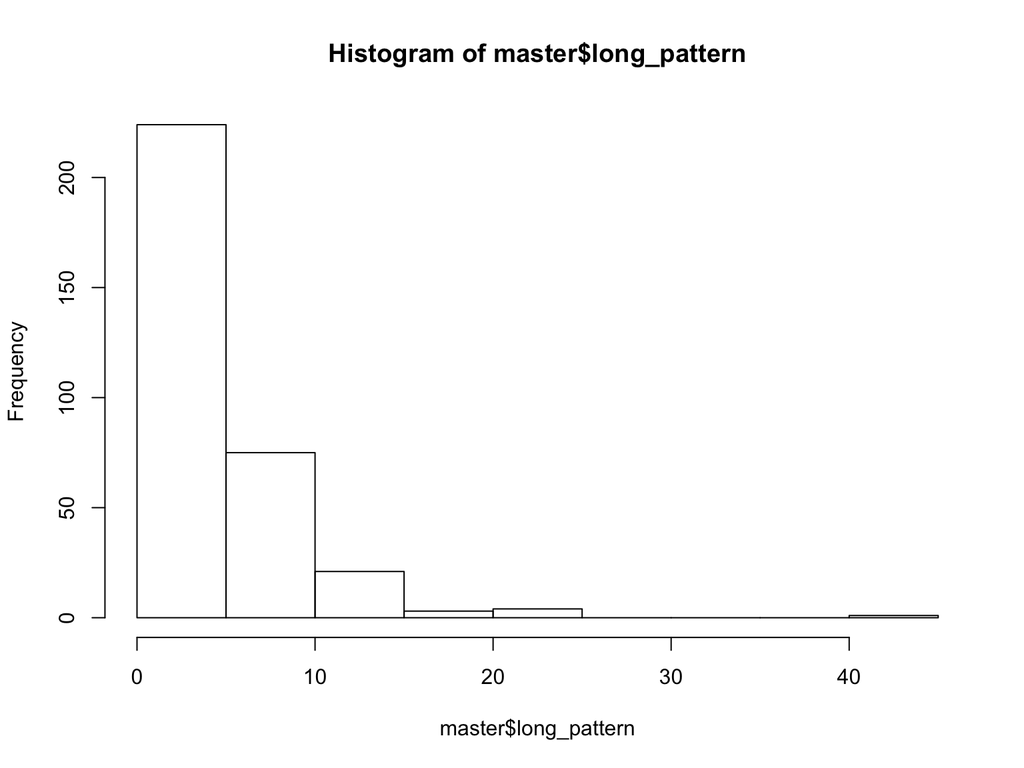

```r
master$long_pattern <- longstring(master[ , c(28:39, 45:55, 62:75, 81:90)])

hist(master$long_pattern)
```

# How to Score

- Not clear what the cut off should be?

```r
master$straight <- master$long_pattern <= (mean(master$long_pattern) + 2*sd(master$long_pattern))

prop.table(table(master$straight))*100
```

```
##
##     FALSE      TRUE
##  4.268293 95.731707
```

# Effect on Statistical Test

| Measure | F-R | R-S |
| --- | --- | --- |
| Original Full | $r = .76$, 95% CI $[.68$, $.82]$ | $r = .12$, 95% CI $[-.03$, $.28]$ |
| Full Straightlining | $r = .70$, 95% CI $[.61$, $.78]$ | $r = .09$, 95% CI $[-.07$, $.25]$ |
| Original Partial | $r = .70$, 95% CI $[.60$, $.77]$ | $r = .18$, 95% CI $[.02$, $.33]$ |
| Partial Straightlining | $r = .70$, 95% CI $[.60$, $.78]$ | $r = .18$, 95% CI $[.01$, $.33]$ |

# Response Patterns - Even Odd Consistency

- Even odd consistency: the correlation between even and odd average items on your scales

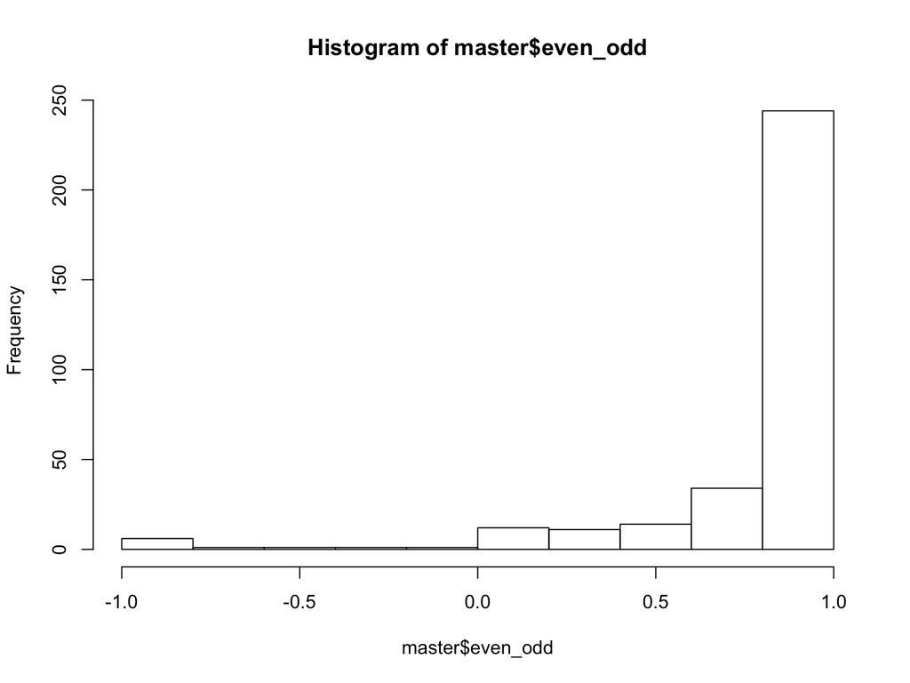

```r
master$even_odd <- evenodd(master[ , c(28:39, 45:55, 62:75, 81:90)],
                           c(length(28:39), length(45:55),
                             length(62:75), length(81:90)))

hist(master$even_odd)
```

# How to Score

```r
master$even_odd_check <- master$even_odd > 0

prop.table(table(master$even_odd_check))*100
```

```
##
##     FALSE      TRUE
##  3.076923 96.923077
```

# Effect on Statistical Test

| Measure | F-R | R-S |
| --- | --- | --- |
| Original Full | $r = .76$, 95% CI $[.68$, $.82]$ | $r = .12$, 95% CI $[-.03$, $.28]$ |
| Full Even-Odd | $r = .74$, 95% CI $[.65$, $.80]$ | $r = .05$, 95% CI $[-.11$, $.21]$ |
| Original Partial | $r = .70$, 95% CI $[.60$, $.77]$ | $r = .18$, 95% CI $[.02$, $.33]$ |
| Partial Even-Odd | $r = .70$, 95% CI $[.61$, $.78]$ | $r = .15$, 95% CI $[-.01$, $.31]$ |

# Response Patterns - Inter-Item Response Variability

- Inter-item response variability and distribution/scale usage
  - Inter-item response variability is the the standard deviation of a participants responses across the scale
  - Very low would indicate straightlining, very high would indicate random responding
  - Similar in idea to using the number of scale options as an indicator of potential pattern (or uniform) responding

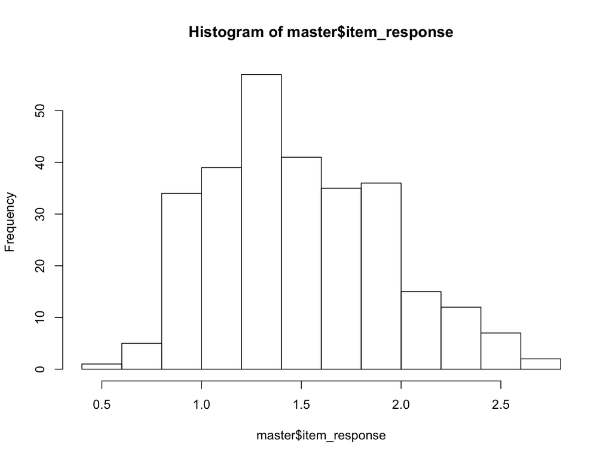

```r
master$item_response <- irv(master[ , c(28:39, 45:55, 62:75, 81:90)])

hist(master$item_response)
```

# How to Score

- Again, the criterion is not obvious or clear, potentially treat like outliers

```r
master$item_response_check <- master$item_response <=
  mean(master$item_response, na.rm = T) + 2*sd(master$item_response, na.rm = T)

prop.table(table(master$item_response_check))*100
```

```
##
##     FALSE      TRUE
##  3.521127 96.478873
```

# Effect on Statistical Test

| Measure | F-R | R-S |
| --- | --- | --- |
| Original Full | $r = .76$, 95% CI $[.68$, $.82]$ | $r = .12$, 95% CI $[-.03$, $.28]$ |
| Full Item | $r = .76$, 95% CI $[.68$, $.82]$ | $r = .20$, 95% CI $[.03$, $.35]$ |
| Original Partial | $r = .70$, 95% CI $[.60$, $.77]$ | $r = .18$, 95% CI $[.02$, $.33]$ |
| Partial Item | $r = .67$, 95% CI $[.56$, $.75]$ | $r = .29$, 95% CI $[.12$, $.44]$ |

# Response Patterns - Person Total Correlation

- Person total correlation: the correlation between the person’s item answers and the average scores of the item answers
  - Very low scores are considered odd - be careful, as short scales show lots of variability in this measure

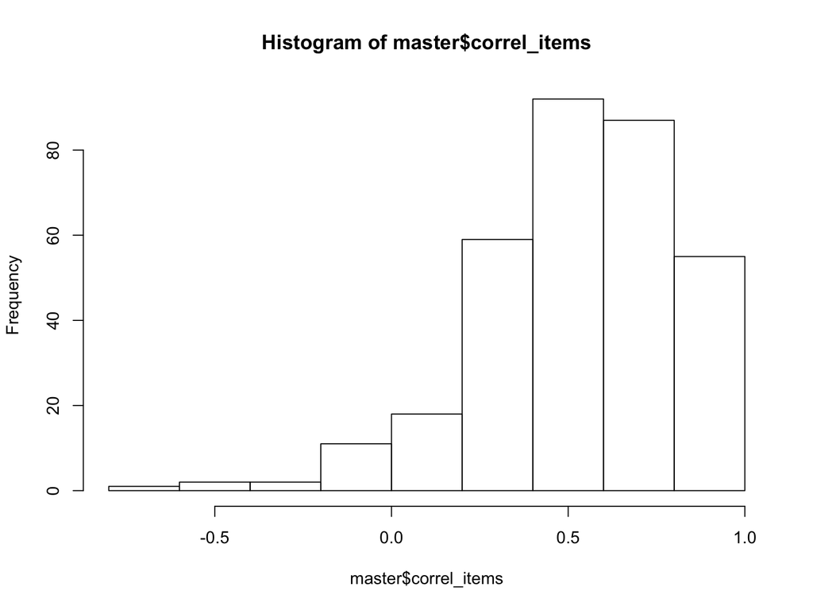

```r
average_items <- apply(master[ , c(28:39, 45:55, 62:75, 81:90)], 2, mean, na.rm = T)

master$correl_items <- apply(master[ , c(28:39, 45:55, 62:75, 81:90)], 1, function(x) {
  cor(x, average_items, use = "pairwise.complete.obs")})

hist(master$correl_items)
```

# How to Score

- Use outlier rules for low scores

```r
master$correl_items_check <- master$correl_items >=
  mean(master$correl_items, na.rm = T) - 2*sd(master$correl_items, na.rm = T)

prop.table(table(master$correl_items_check))*100
```

```
##
##     FALSE      TRUE
##  4.587156 95.412844
```

# Effect on Statistical Test

| Measure | F-R | R-S |
| --- | --- | --- |
| Original Full | $r = .76$, 95% CI $[.68$, $.82]$ | $r = .12$, 95% CI $[-.03$, $.28]$ |
| Full Person | $r = .75$, 95% CI $[.67$, $.82]$ | $r = .03$, 95% CI $[-.13$, $.19]$ |
| Original Partial | $r = .70$, 95% CI $[.60$, $.77]$ | $r = .18$, 95% CI $[.02$, $.33]$ |
| Partial Person | $r = .62$, 95% CI $[.50$, $.71]$ | $r = .06$, 95% CI $[-.10$, $.22]$ |

# Response Patterns - Mahalanobis Distance

- Mahalanobis distance: a measure of a participant’s scores from the centriod of all the scores
  - This method is a more traditional outlier analysis with cut-off scores based on the number of items and a $\chi^2$ distribution

```r
master$mahal <- mahalanobis(master[ , c(28:39, 45:55, 62:75, 81:90)],
                            center = colMeans(master[ , c(28:39, 45:55, 62:75, 81:90)], na.rm = T),
                            cov = cov(master[ , c(28:39, 45:55, 62:75, 81:90)],
                                      use = "pairwise.complete.obs"))
alpha <- .001
cutoff <- (qchisq(p = 1 - alpha, df = ncol(master[ , c(28:39, 45:55, 62:75, 81:90)])))

master$mahal_check <- master$mahal < cutoff

prop.table(table(master$mahal_check)) * 100
```

```
##
##     FALSE      TRUE
##  7.746479 92.253521
```

# Effect on Statistical Test

| Measure | F-R | R-S |
| --- | --- | --- |
| Original Full | $r = .76$, 95% CI $[.68$, $.82]$ | $r = .12$, 95% CI $[-.03$, $.28]$ |
| Full Mahal | $r = .75$, 95% CI $[.67$, $.82]$ | $r = .11$, 95% CI $[-.06$, $.27]$ |
| Original Partial | $r = .70$, 95% CI $[.60$, $.77]$ | $r = .18$, 95% CI $[.02$, $.33]$ |
| Partial Mahal | $r = .72$, 95% CI $[.62$, $.80]$ | $r = .13$, 95% CI $[-.05$, $.30]$ |

# Response Patterns - Other Options

- More advanced options:
  - Guttman errors
  - Gendre’s functional method
  - IRT models

# How many?

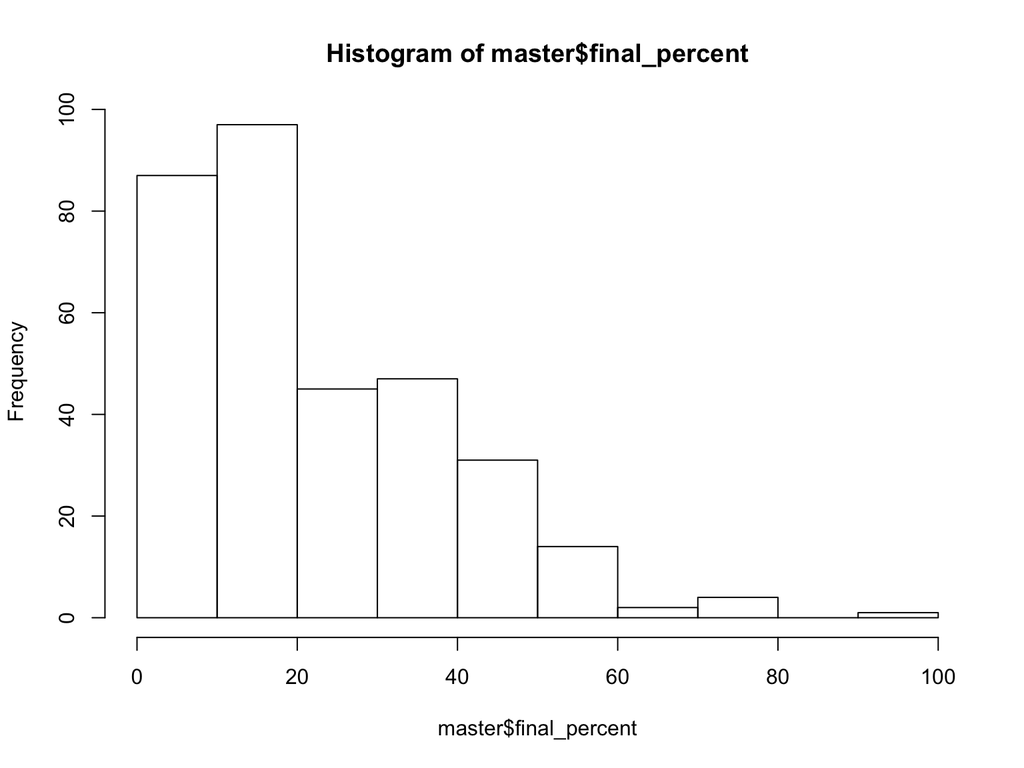

# Final Thoughts

- Generally:
  - In large correlation effects, generally doesn’t change the effect much
  - In small correlation effects, about half don’t change, other half decrease
  - Other studies show the reduction in noise increases an effect size
- Does not appear to be a “reaction” to including visible checks
- No one rule is useful, should combine rules
- Suggestion is to take the overall percent marked as “bad”, use a cut-off based on an overall global representation of “low effort”
- Pre-register!
- Coming soon: videos for R, JASP, SPSS describing these with more comments on procedure and thoughts, keep an eye on the OSF page!

# Want to learn more?

- Twitter is the best!
- Read reddit … seriously
- Working group?

THANK YOU!